# Grammar of Graphics practice

## Previous year’s explorations

### An example to warm up with

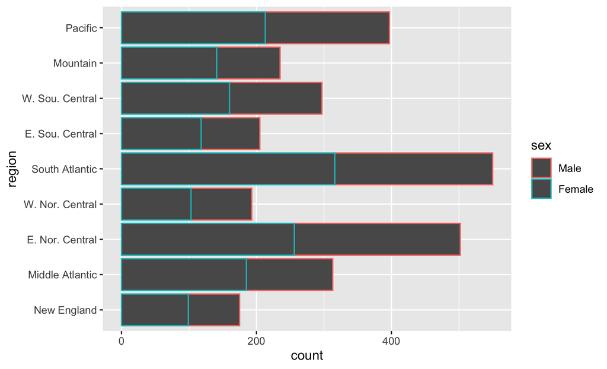

```r
gss_sm |> ggplot(aes(y = region, color = sex)) + geom_bar()
```

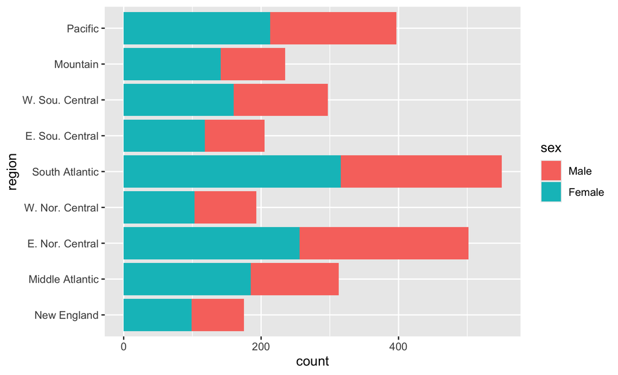

```r
gss_sm |> ggplot(aes(y = region, fill = sex)) + geom_bar()
```

```r
glimpse(penguins)
```

```
Rows: 344
Columns: 8
$ species           <fct> Adelie, Adelie, Adelie, Adelie, Adelie, Adelie, Adel…
$ island            <fct> Torgersen, Torgersen, Torgersen, Torgersen, Torgerse…
$ bill_length_mm    <dbl> 39.1, 39.5, 40.3, NA, 36.7, 39.3, 38.9, 39.2, 34.1, …
$ bill_depth_mm     <dbl> 18.7, 17.4, 18.0, NA, 19.3, 20.6, 17.8, 19.6, 18.1, …
$ flipper_length_mm <int> 181, 186, 195, NA, 193, 190, 181, 195, 193, 190, 186…
$ body_mass_g       <int> 3750, 3800, 3250, NA, 3450, 3650, 3625, 4675, 3475, …
$ sex               <fct> male, female, female, NA, female, male, female, male…
$ year              <int> 2007, 2007, 2007, 2007, 2007, 2007, 2007, 2007, 2007…
```

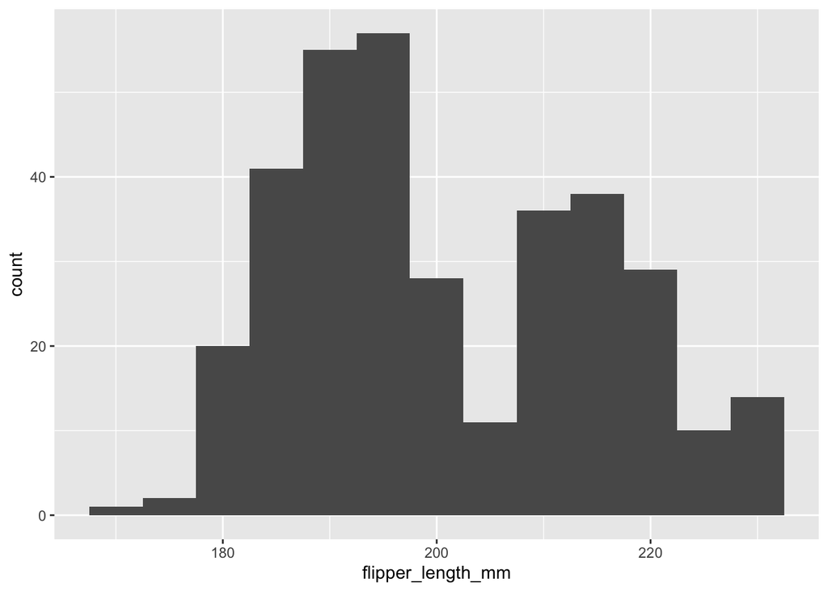

```r
penguins |> ggplot(aes(x = flipper_length_mm)) + geom_histogram(binwidth = 5)
```

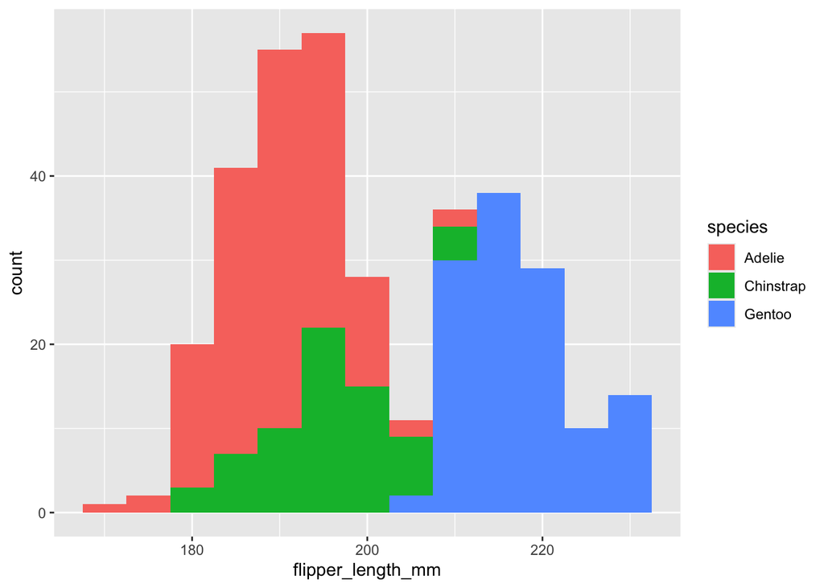

```r
penguins |> ggplot(aes(x = flipper_length_mm, fill = species)) + geom_histogram(binwidth = 5)
```

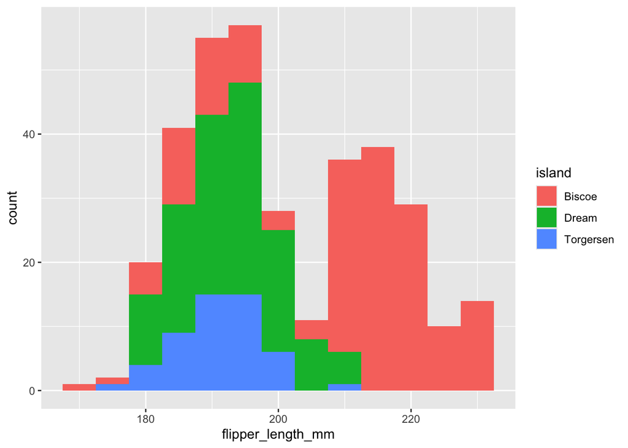

```r
penguins |> ggplot(aes(x = flipper_length_mm, fill = island)) + geom_histogram(binwidth = 5)
```

### Make lots of your own experiments

Can we show two categorical variables on one plot?

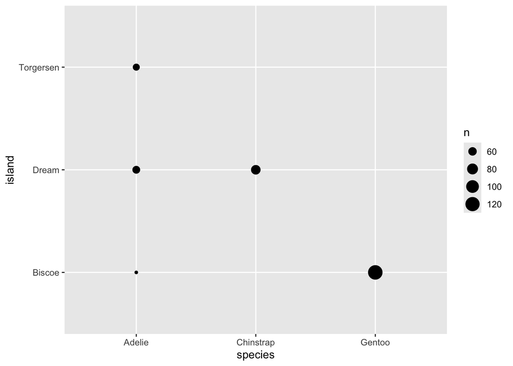

```r
penguins |> ggplot(aes(species, island)) + geom_count()
```

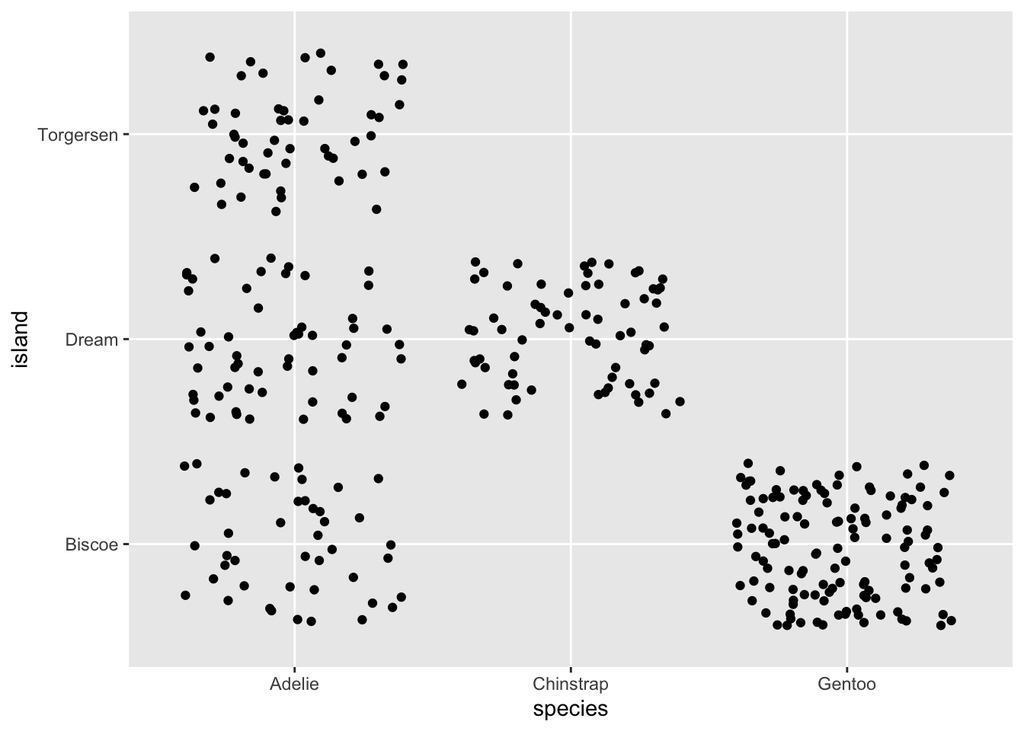

```r
penguins |> ggplot(aes(species, island)) + geom_jitter()
```

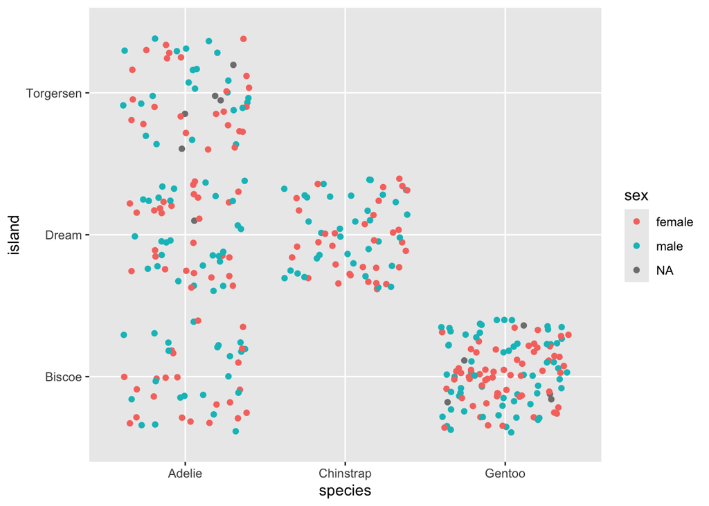

```r
penguins |> ggplot(aes(species, island)) + geom_jitter(aes(color = sex)) # a bit random for my taste
```

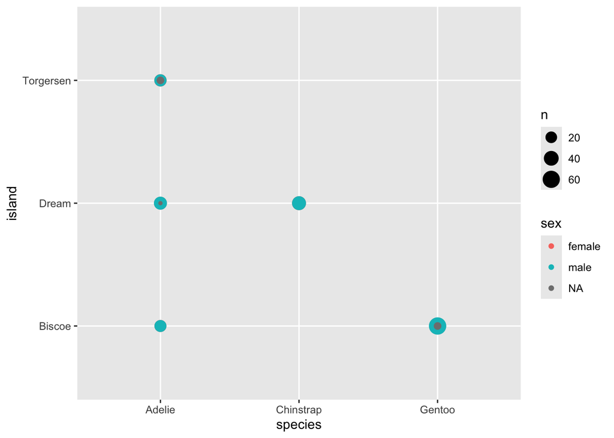

```r
penguins |> ggplot(aes(species, island)) + geom_count(aes(color = sex)) # not sure I understand this one
```

### Make the plots look better

- Add labels with `labs(x = "...", y = "...", title = "...", color = "...", fill = "...")`.

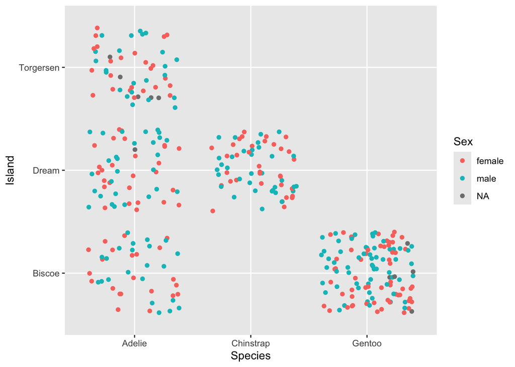

```r
penguins |> ggplot(aes(species, island, color = sex)) + geom_jitter() +
  labs(x = "Species", y = "Island", color = "Sex")
```

- Make the text bigger with `theme(text = element_text(size = 15))`.
- Turn off the grey shading with `theme_bw()`
- Always use `+` to “add” parts of a ggplot together.

### gapminder experiments

```r
str(gapminder)
```

```
tibble [1,704 × 6] (S3: tbl_df/tbl/data.frame)
 $ country  : Factor w/ 142 levels "Afghanistan",..: 1 1 1 1 1 1 1 1 1 1 ...
 $ continent: Factor w/ 5 levels "Africa","Americas",..: 3 3 3 3 3 3 3 3 3 3 ...
 $ year     : int [1:1704] 1952 1957 1962 1967 1972 1977 1982 1987 1992 1997 ...
 $ lifeExp  : num [1:1704] 28.8 30.3 32 34 36.1 ...
 $ pop      : int [1:1704] 8425333 9240934 10267083 11537966 13079460 14880372 12881816 13867957 16317921 22227415 ...
 $ gdpPercap: num [1:1704] 779 821 853 836 740 ...
```

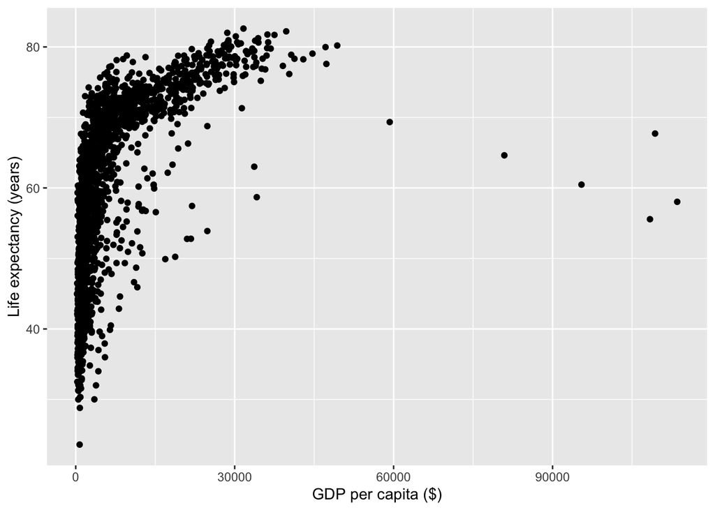

```r
gapminder |> ggplot(aes(x = gdpPercap, y = lifeExp )) + geom_point() +
  labs(x = "GDP per capita ($)", y = "Life expectancy (years)")
```

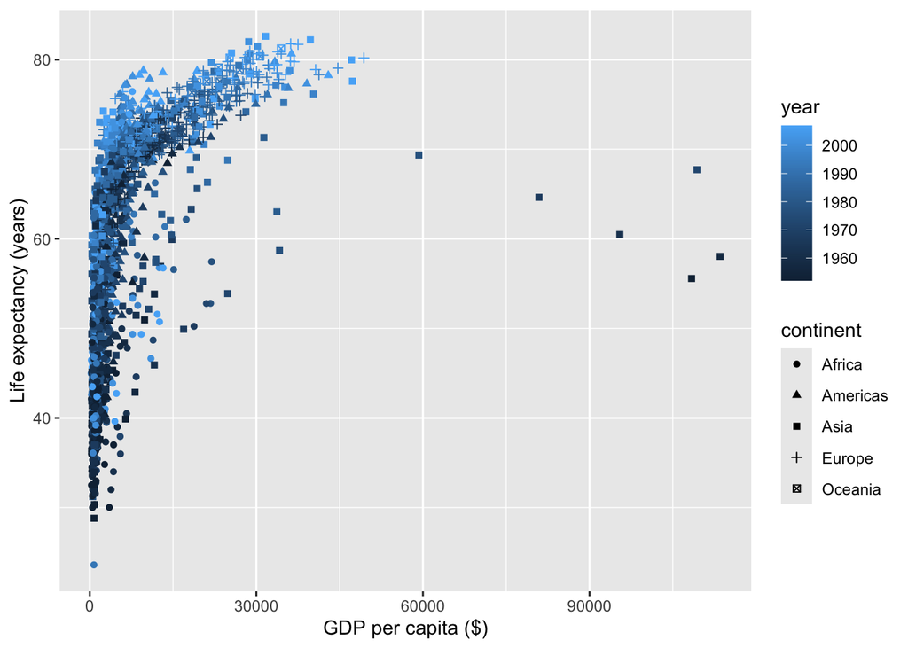

```r
gapminder |> ggplot(aes(x = gdpPercap, y = lifeExp,
                        color = year, shape = continent)) + geom_point() +
  labs(x = "GDP per capita ($)", y = "Life expectancy (years)")
```

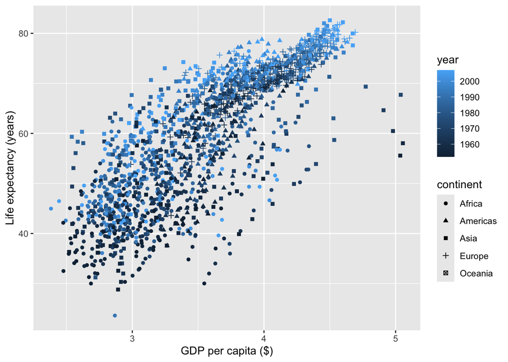

```r
gapminder |> ggplot(aes(x = log10(gdpPercap), y = lifeExp,
                        color = year, shape = continent)) + geom_point() +
  labs(x = "GDP per capita ($)", y = "Life expectancy (years)")
```

Can we see how GDP per capita varies with year? And maybe continent too?

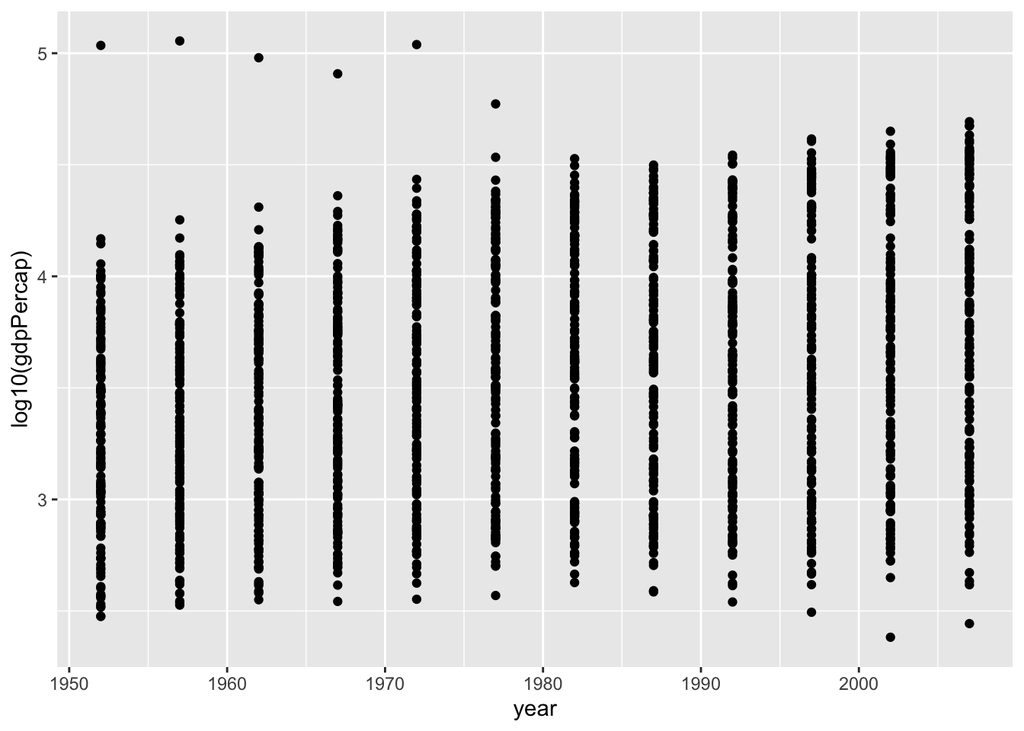

```r
gapminder |> ggplot(aes(y = log10(gdpPercap), x = year)) + geom_point()
```

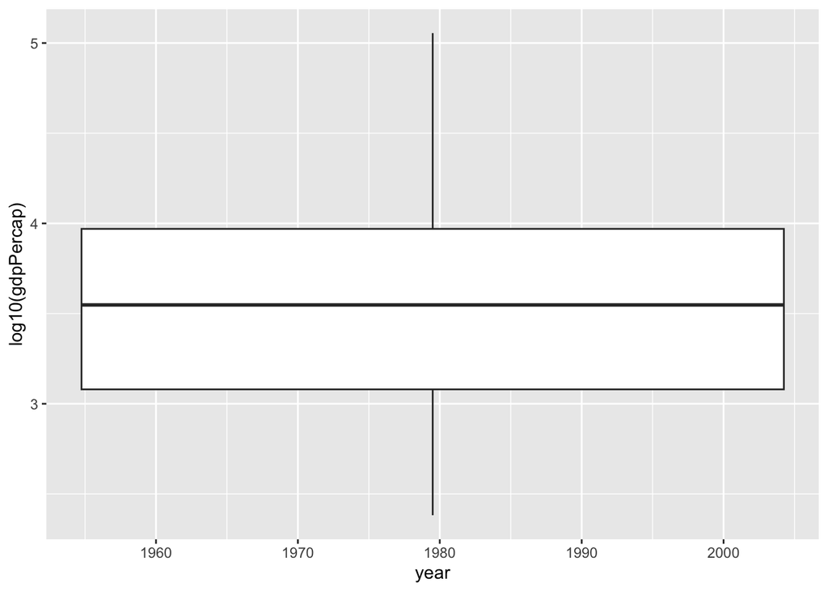

```r
gapminder |> ggplot(aes(y = log10(gdpPercap), x = year)) + geom_boxplot() # ugh!!
```

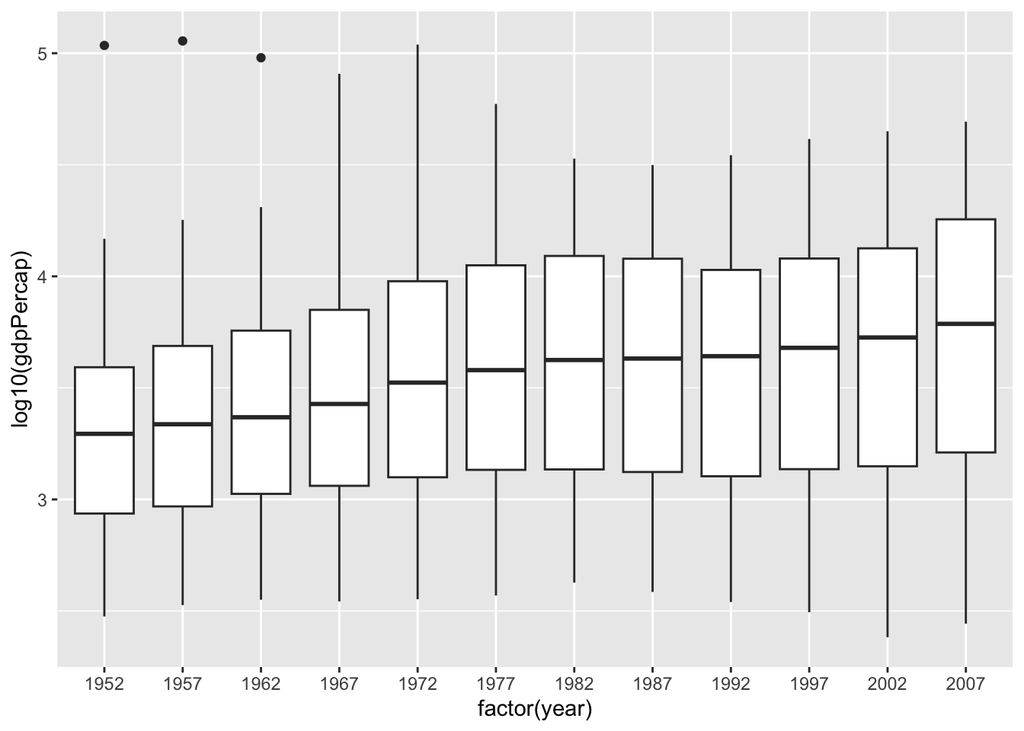

```r
gapminder |> ggplot(aes(y = log10(gdpPercap), x = factor(year))) + geom_boxplot()
```

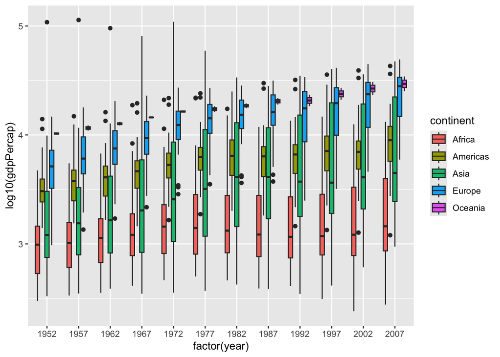

```r
gapminder |> ggplot(aes(y = log10(gdpPercap), x = factor(year), fill = continent)) + geom_boxplot()
```

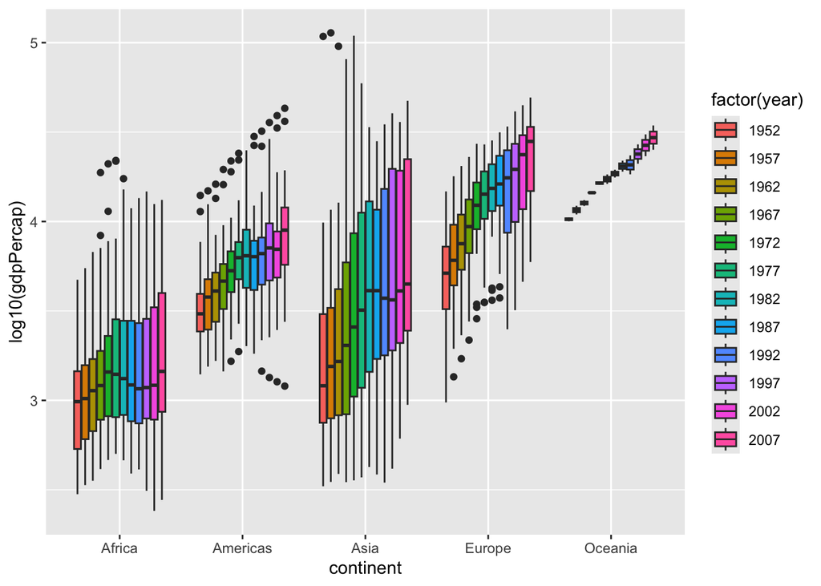

```r
gapminder |> ggplot(aes(y = log10(gdpPercap), fill = factor(year), x = continent)) + geom_boxplot()
```

### Examples from previous courses

Left here as more examples.

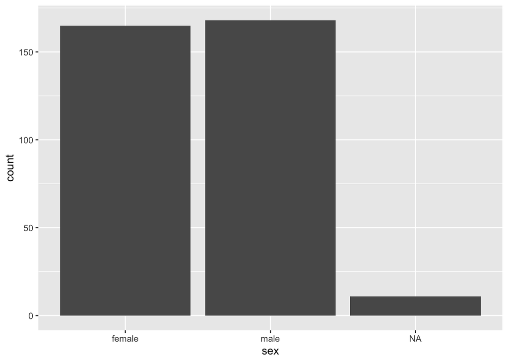

```r
penguins |> ggplot(aes(x = sex)) + geom_bar()
```

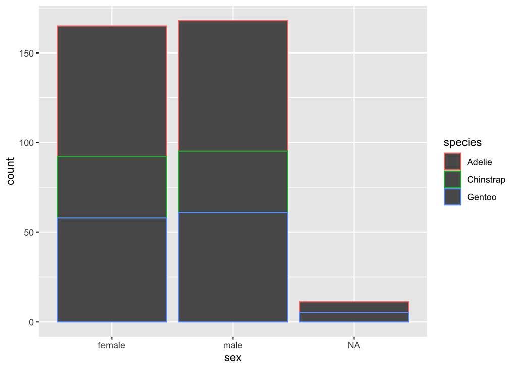

```r
penguins |> ggplot(aes(x = sex, color = species)) + geom_bar()
```

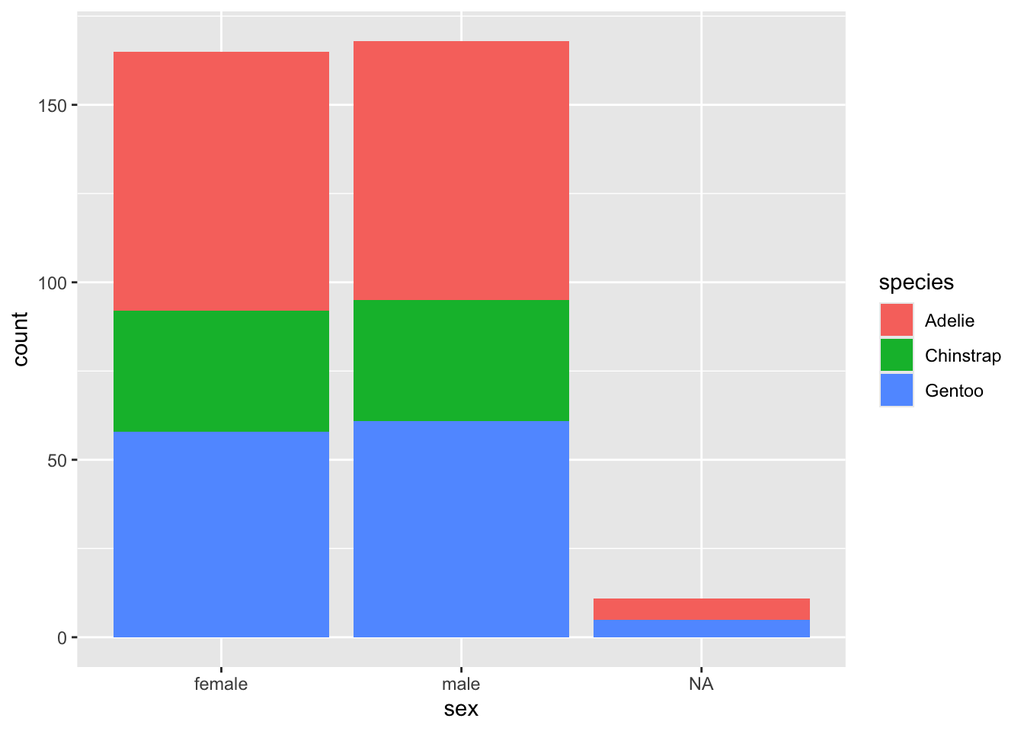

```r
penguins |> ggplot(aes(x = sex, fill = species)) + geom_bar()
```

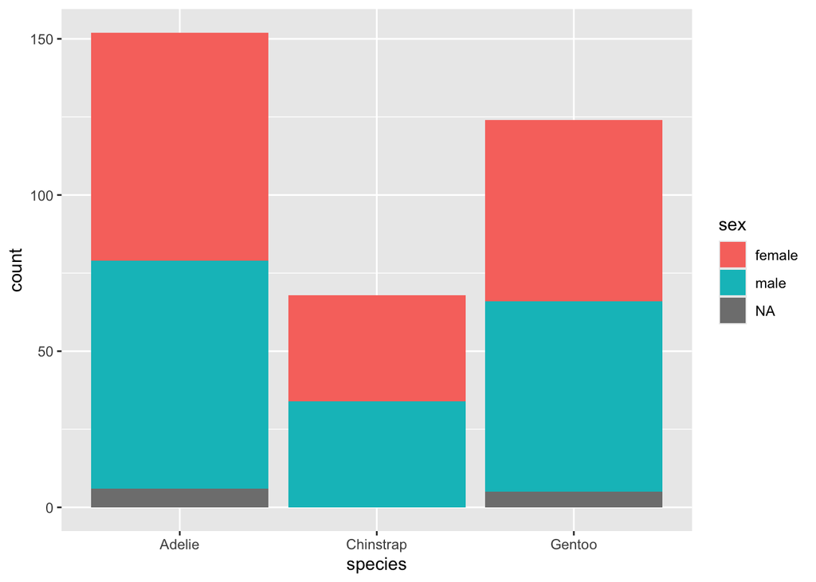

```r
penguins |> ggplot(aes(fill = sex, x = species)) + geom_bar()
```

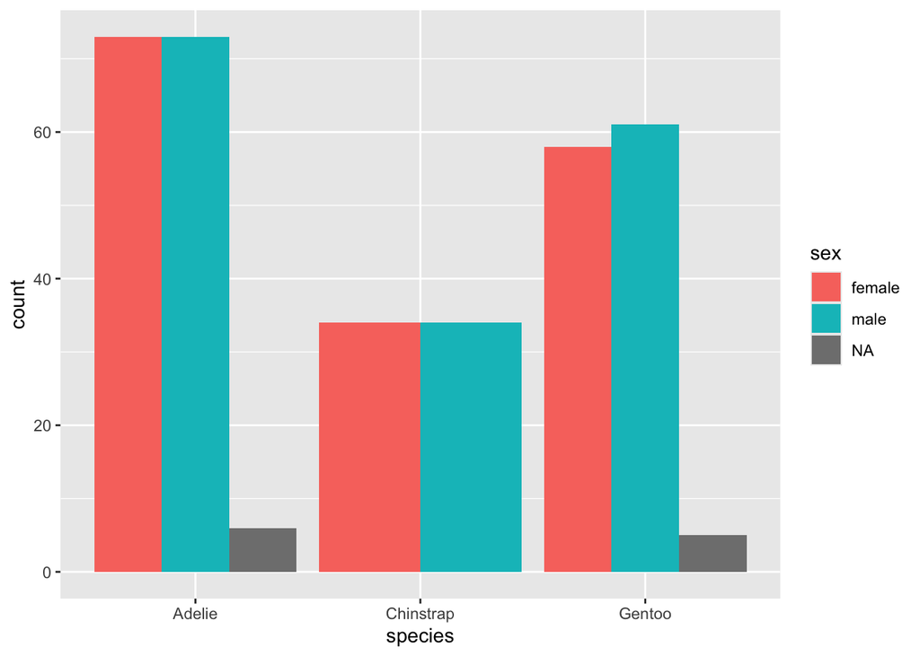

```r
penguins |> ggplot(aes(fill = sex, x = species)) + geom_bar(position = "dodge")
```

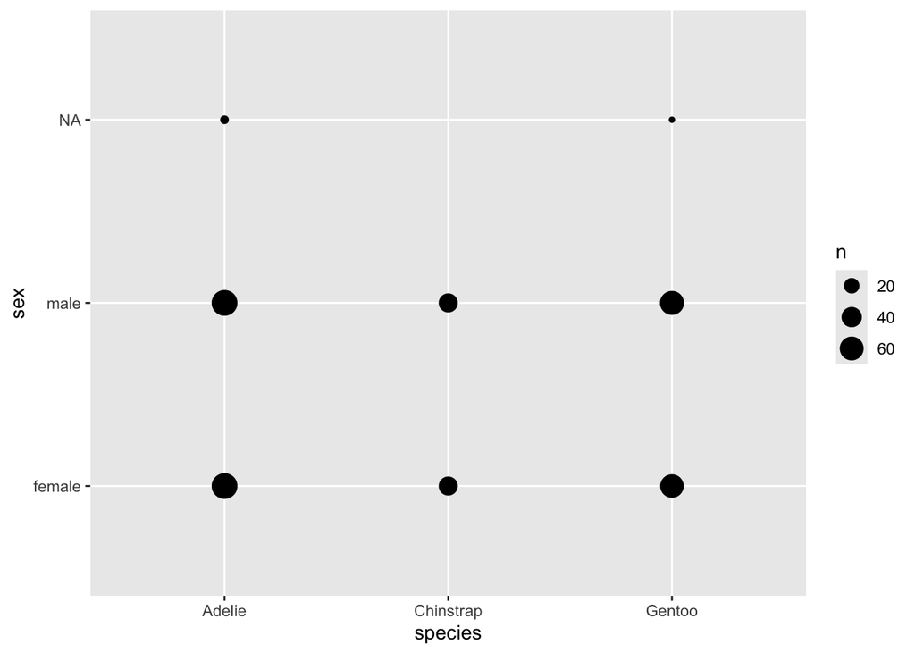

```r
penguins |> ggplot(aes(x = species, y = sex)) + geom_count()
```

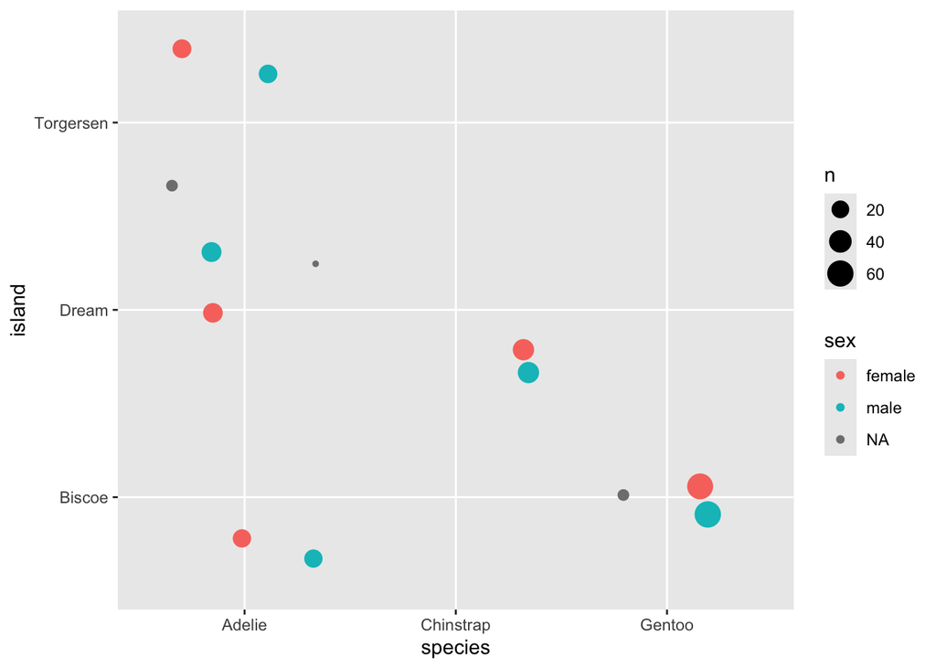

```r
# penguins |> ggplot(aes(x = species)) + geom_count() # fails can't drqw with only one of x or y
penguins |> ggplot(aes(x = species, y = island, color = sex)) + geom_count(position = "jitter") # terrible, but fun!
```

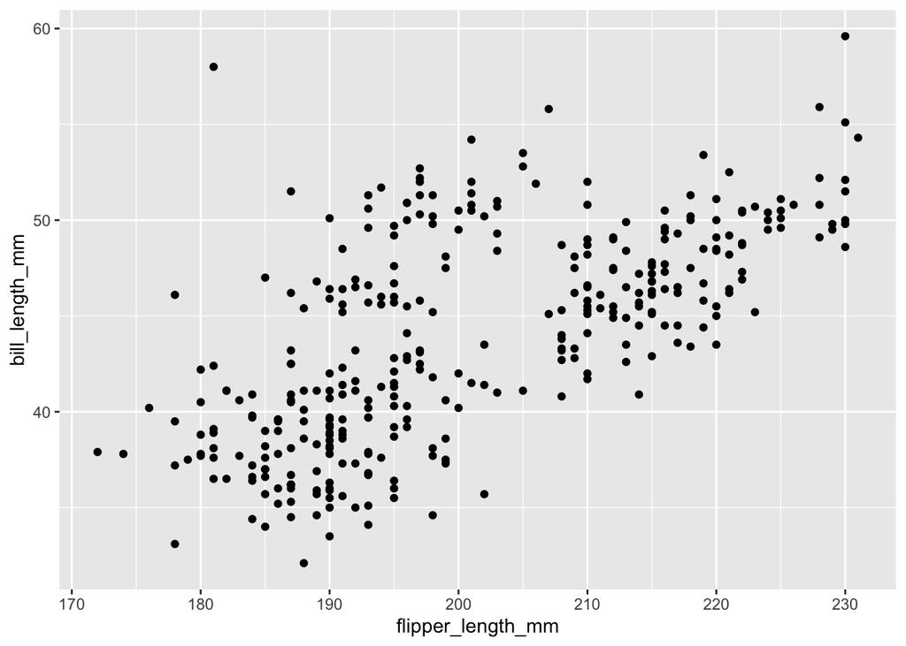

```r
penguins |> ggplot(aes(flipper_length_mm, bill_length_mm)) + geom_point()
```

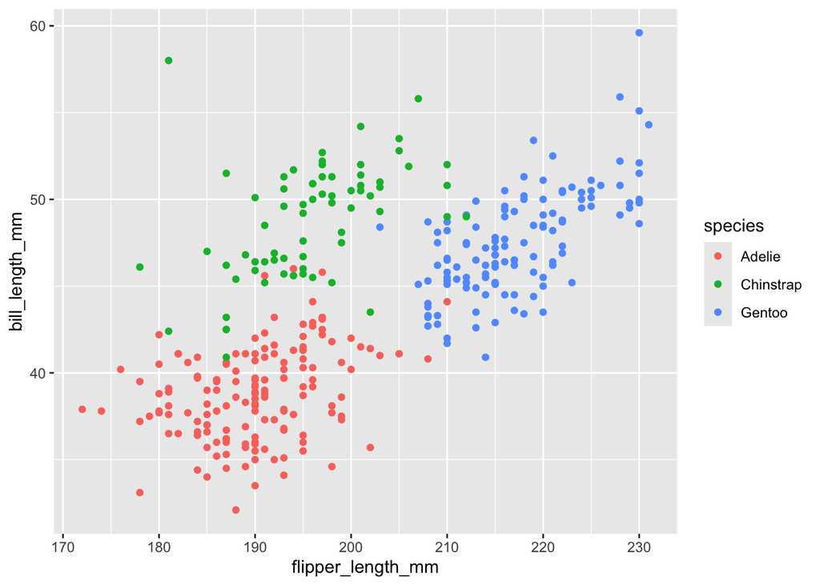

```r
penguins |> ggplot(aes(flipper_length_mm, bill_length_mm, color = species)) + geom_point()
```

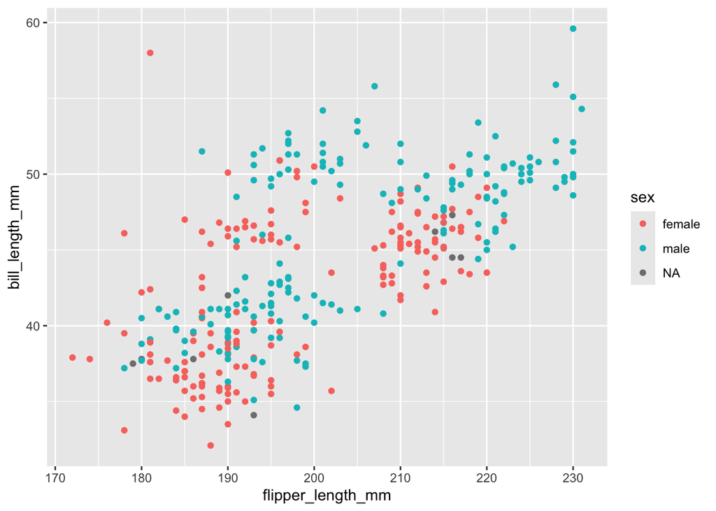

```r
penguins |> ggplot(aes(flipper_length_mm, bill_length_mm, color = sex)) + geom_point()
```

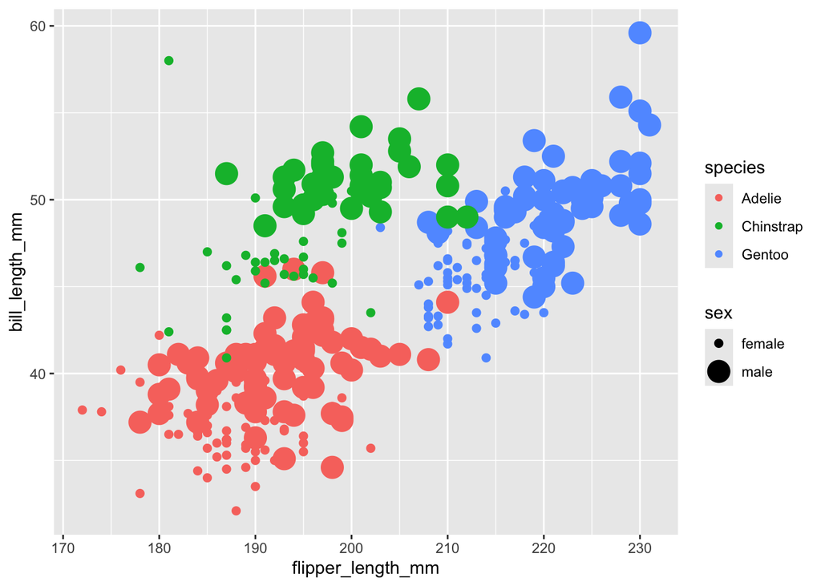

```r
penguins |> na.omit() |> ggplot(aes(flipper_length_mm, bill_length_mm, color = species, size = sex)) + geom_point()
```

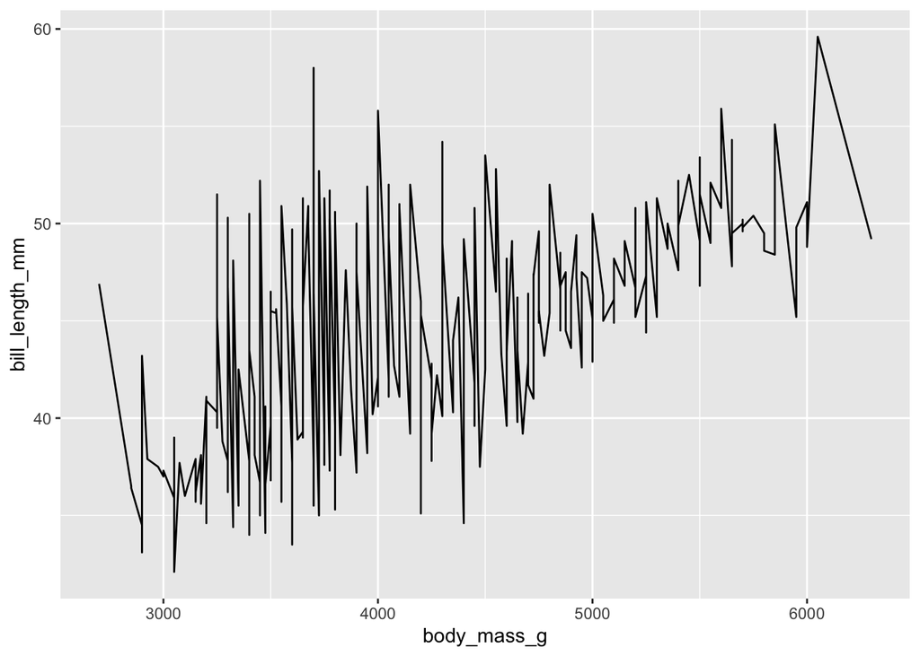

```r
penguins |> ggplot(aes(body_mass_g, bill_length_mm)) + geom_line() # works, but silly
```

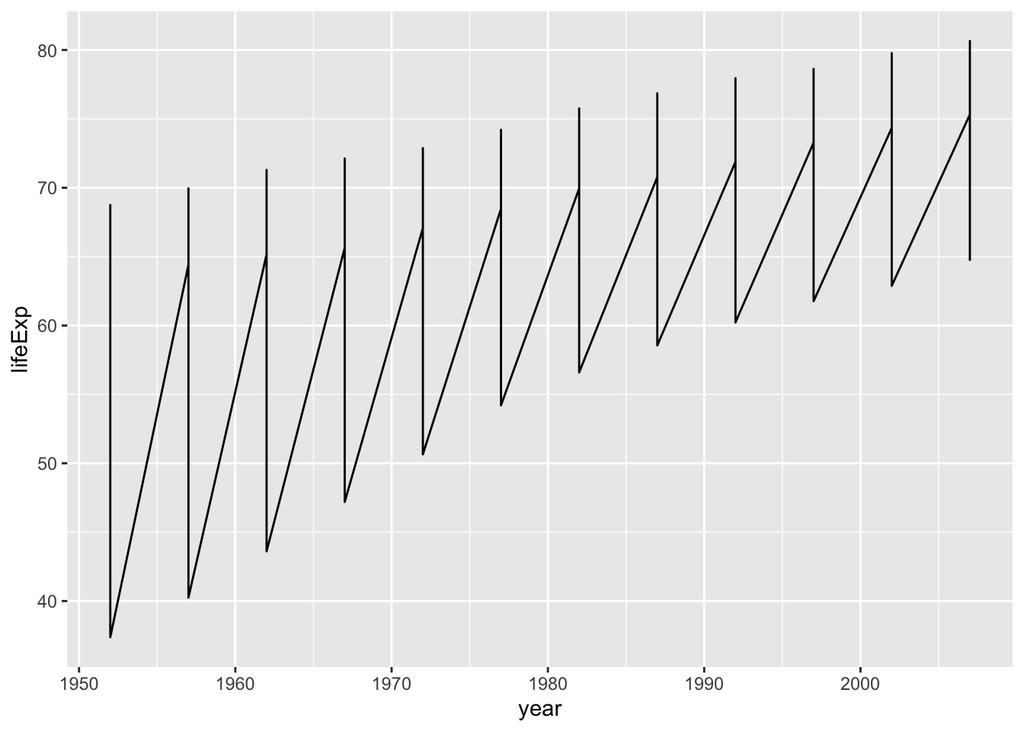

```r
gapminder |> filter(country %in% c("China", "Canada", "India", "France", "Argentina", "Lybia")) |>
  ggplot(aes(year, lifeExp)) + geom_line()
```

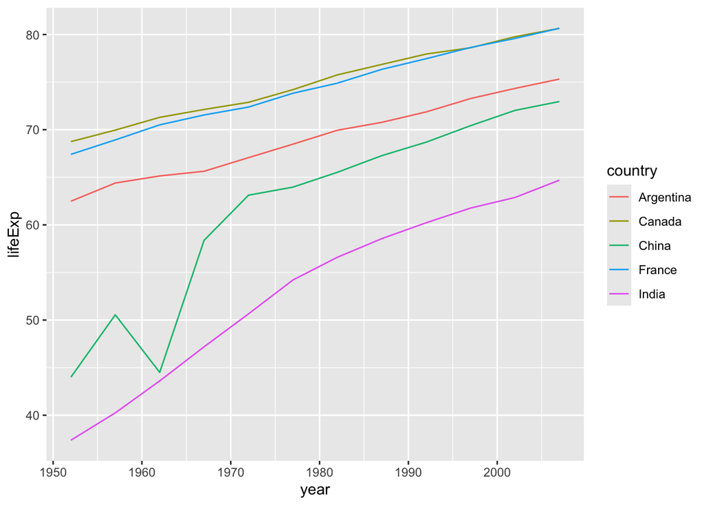

```r
gapminder |> filter(country %in% c("China", "Canada", "India", "France", "Argentina", "Lybia")) |>
  ggplot(aes(year, lifeExp, color = country)) + geom_line()
```

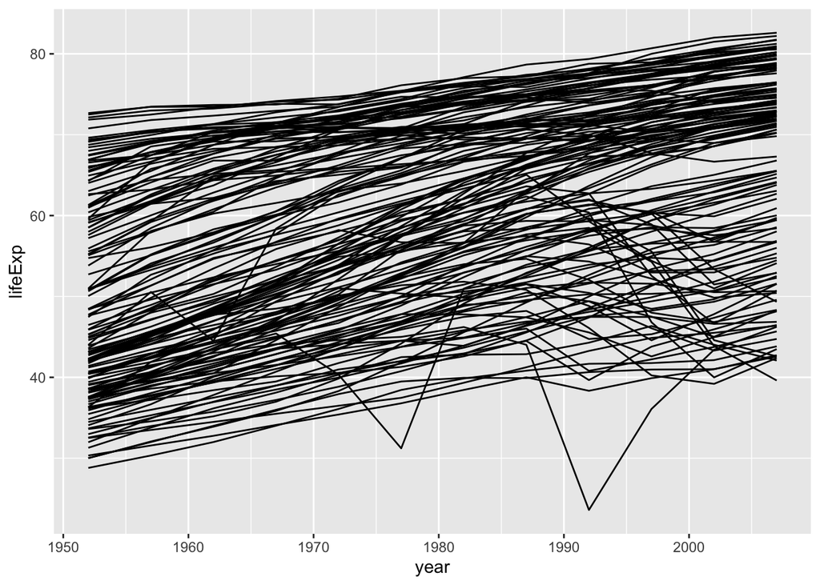

```r
gapminder |>
  ggplot(aes(year, lifeExp, group = country)) + geom_line()
```

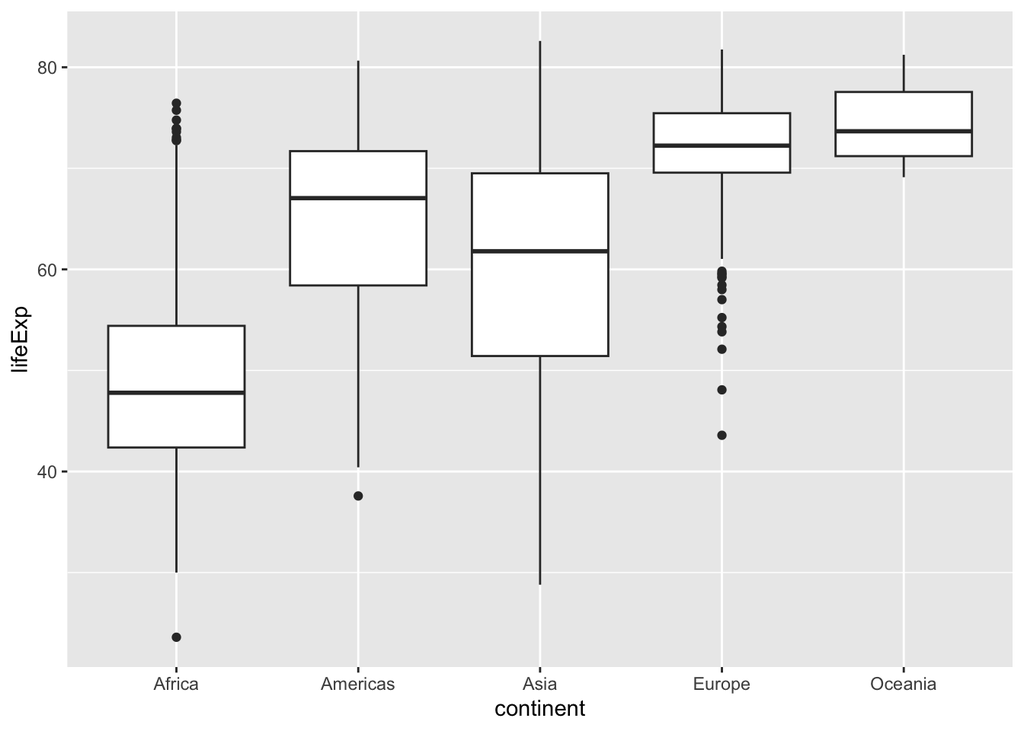

```r
gapminder |> ggplot(aes(x = continent, y = lifeExp)) + geom_boxplot()
```

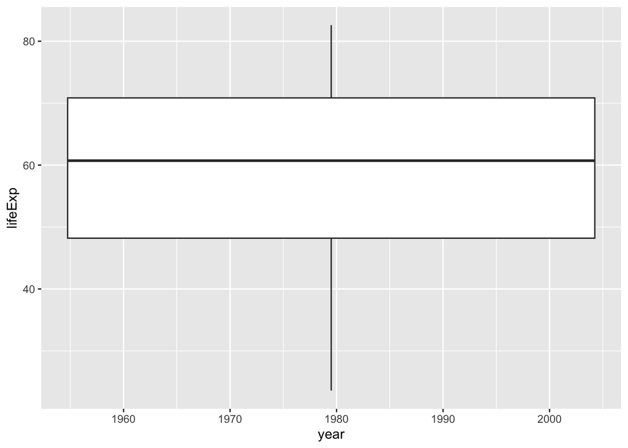

```r
gapminder |> ggplot(aes(x = year, y = lifeExp)) + geom_boxplot()  # doesn't work the way I hoped!
```

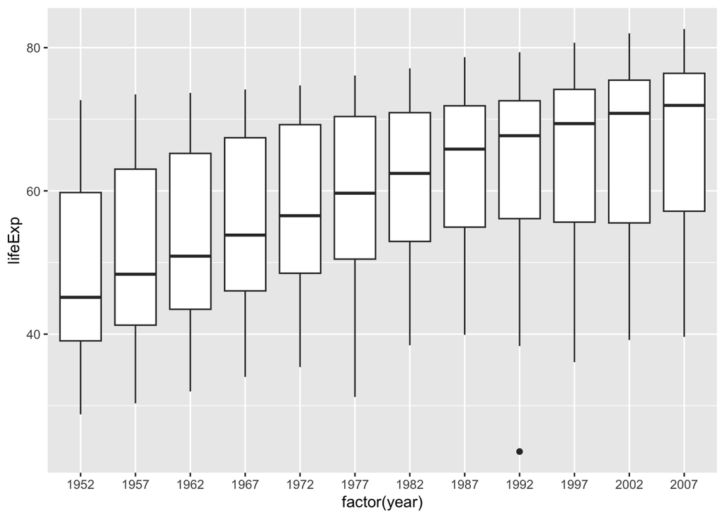

```r
gapminder |> ggplot(aes(x = factor(year), y = lifeExp)) + geom_boxplot()
```

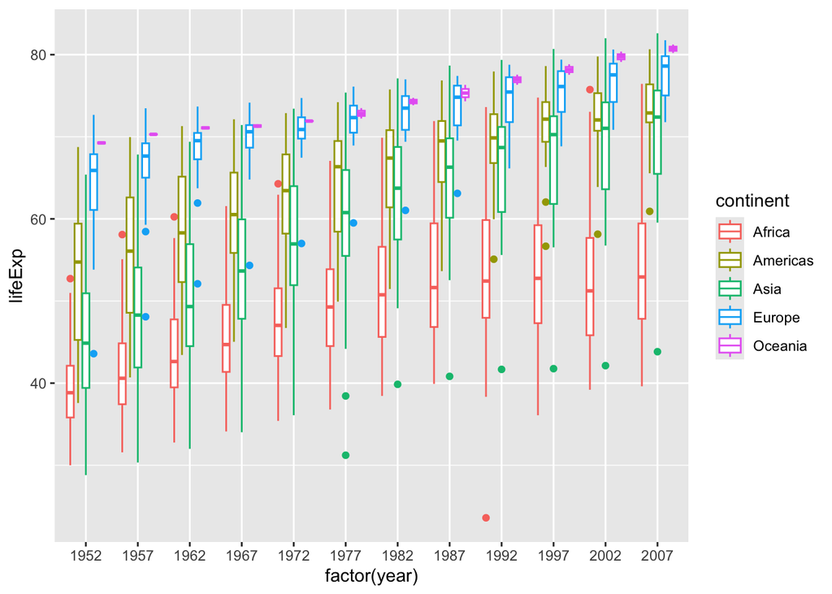

```r
gapminder |> ggplot(aes(x = factor(year), y = lifeExp, color = continent)) + geom_boxplot()
```

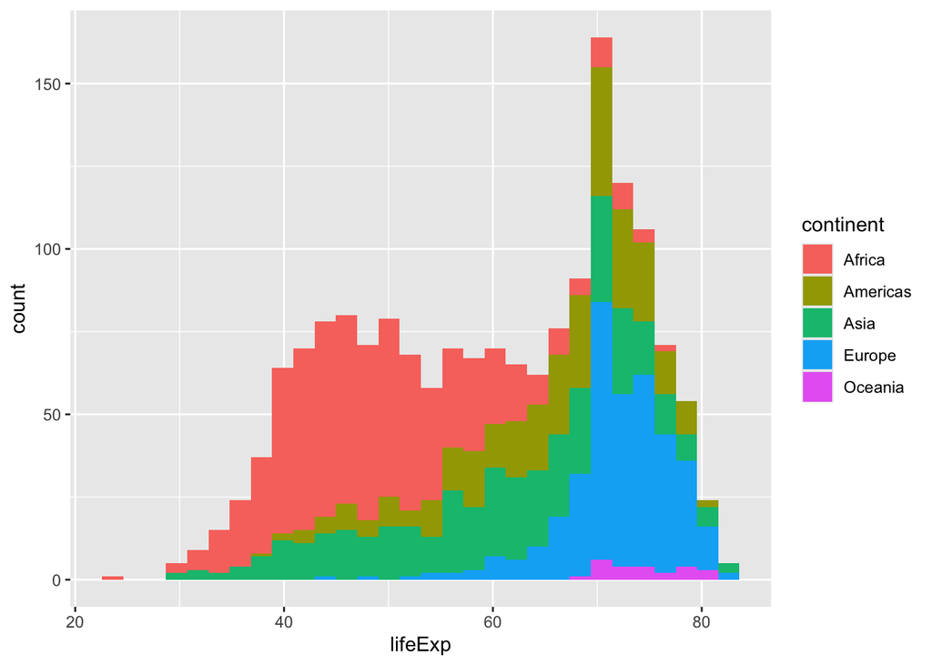

```r
gapminder |> ggplot(aes(lifeExp, fill = continent)) + geom_histogram()
```

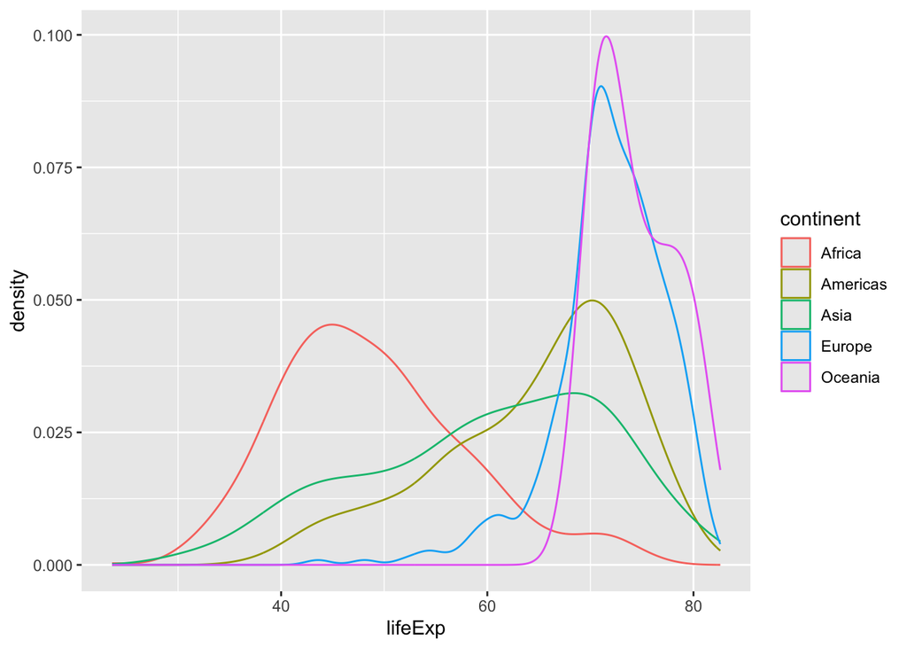

```r
gapminder |> ggplot(aes(lifeExp, color = continent)) + geom_density()
```

```
No summary function supplied, defaulting to `mean_se()`
```

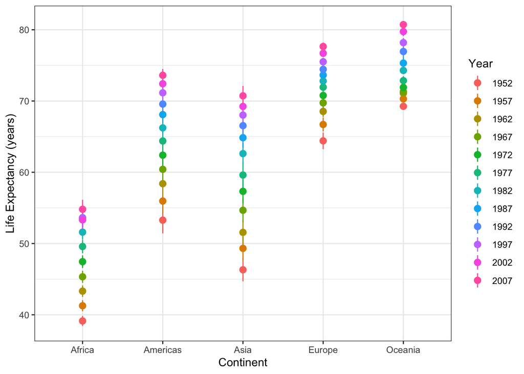

```r
gapminder |> ggplot(aes(y = lifeExp, x = continent, color = factor(year))) + stat_summary() +
  labs(x = "Continent", y = "Life Expectancy (years)", color = "Year") +
  theme_bw()
```